# Session 4: Linking and joining data & SQL

## NYC flights: weather conditions vs delays

```r
plane_delays_weather <- tbl(db_nyc, "flights") |>
  inner_join(tbl(db_nyc, "weather"), by = c("time_hour", "origin")) |>
  filter(!is.na(temp), !is.na(arr_delay), !is.na(wind_speed)) |>
  collect()
```

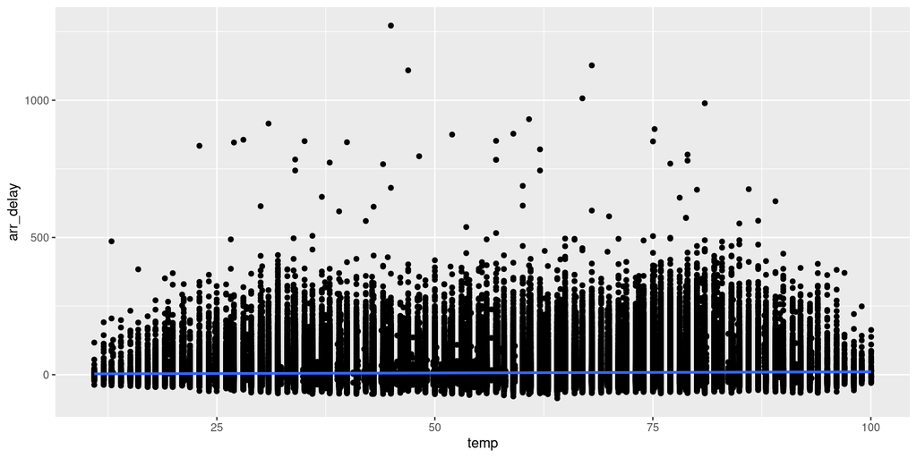

```r
plane_delays_weather |>
  ggplot(aes(x = temp, y = arr_delay)) +
  geom_point() +
  geom_smooth(method = "lm", formula = y ~ x)
```

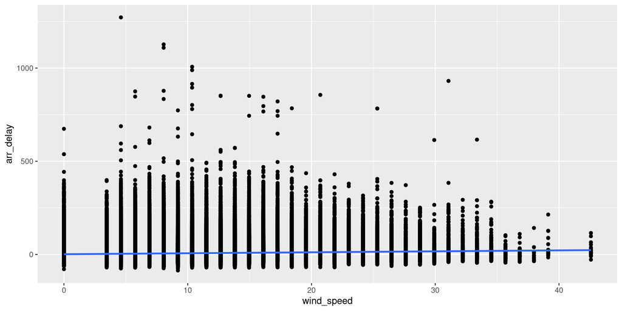

```r
plane_delays_weather |>
  ggplot(aes(x = wind_speed, y = arr_delay)) +
  geom_point() +
  geom_smooth(method = "lm", formula = y ~ x)
```

## Should you learn SQL properly?

It depends!

- how often and how advanced do you want to use it?
- do you want to stay in the `R` ecosystem or extend your knowledge beyond it?
- how many clients will use your database?

There is an interesting video discussing the question in more detail here: https://youtu.be/gdzONbwfWk0

# When done, `dbDisconnect`

Whenever you are done working with a database, you should disconnect from it:

```r
dbDisconnect(db)
```

- This closes the connection, discards all pending work, and frees resources

# Homework

Tomorrow, we will use the software Docker to simulate a database server. Install the software and make sure it works. You can follow the guide I made here:

https://youtu.be/iMyCdd5nP5U

# Wrap Up

# References

Weidmann, Nils B. 2023. *Data Management for Social Scientists: From Files to Databases*. 1st ed. Cambridge University Press. https://doi.org/10.1017/9781108990424.

Wickham, Hadley, Mine Çetinkaya-Rundel, and Garrett Grolemund. 2023. *R for Data Science: Import, Tidy, Transform, Visualize, and Model Data*. 2nd edition. O’Reilly.